# Homework 10

Tessa Lanzel

2023-04-24

## Github: https://github.com/tlanzel/DS202-HW10

```r
acc = read.csv("https://raw.githubusercontent.com/yumouqiu/DS202-Spring2023/main/Practice/data/fars2016/accident.csv")
person = read.csv("https://raw.githubusercontent.com/yumouqiu/DS202-Spring2023/main/Practice/data/fars2016/person.csv")
vehicle = read.csv("https://raw.githubusercontent.com/yumouqiu/DS202-Spring2023/main/Practice/data/fars2016/vehicle.csv")
```

```r
library(tidyverse)
```

```r
library(ggplot2)
```

### Part 1

*Are there some days of the week where more accidents happen than on others (use variable DAY_WEEK)?*

```r
view(acc)
acc %>% group_by(DAY_WEEK) %>% count() %>% arrange(desc(n))
```

```
## # A tibble: 7 × 2
## # Groups:   DAY_WEEK [7]
##   DAY_WEEK     n
##      <int> <int>
## 1        7  6104
## 2        6  5352
## 3        1  5303
## 4        5  4662
## 5        2  4501
## 6        4  4388
## 7        3  4129
```

The data shows that more accidents happen during the weekend, with the top two days being Friday and Saturday. The least accidents occur on Tuesdays.  
*What time of the day do accidents happen (use variable HOUR)?*

```r
acc %>% group_by(HOUR) %>% count() %>% arrange(desc(n))
```

```
## # A tibble: 25 × 2
## # Groups:   HOUR [25]
##     HOUR     n
##    <int> <int>
##  1    18  1984
##  2    20  1919
##  3    17  1913
##  4    19  1902
##  5    16  1808
##  6    21  1801
##  7    15  1731
##  8    22  1650
##  9    14  1567
## 10    13  1514
## # … with 15 more rows
```

Accidents are more likely to occur at night, with the top three times being 18 (6:00 pm), 20 (8:00 pm), and 17 (5:00 pm). The highest number of accidents occur around 6:00 pm - which could possibly be due to rush hour traffic. The least amount of accidents occur at 4 (4:00 am).  
*What is the number of accidents with at least one drunk driver (use variable DRUNK_DR)?*

```r
sum(acc$DRUNK_DR >= 1)
```

```
## [1] 8720
```

The number of accidents with at least one drunk driver is 8720.

### Part 2

*Connect to the person table. Identify drivers (PER_TYP == 1, see fars manual ) and subset on them.*

```r
per1 = person %>% filter(PER_TYP == 1)
```

*Join accident and driver table (work out which variable(s) to use)*

```r
acc.join = left_join(per1, acc, by = c("ST_CASE","HOUR"))
View(acc.join)
```

*Tally the number of accidents by day of the week (DAY_WEEK), hour of the day (HOUR) and gender (SEX). Visualize the results!*

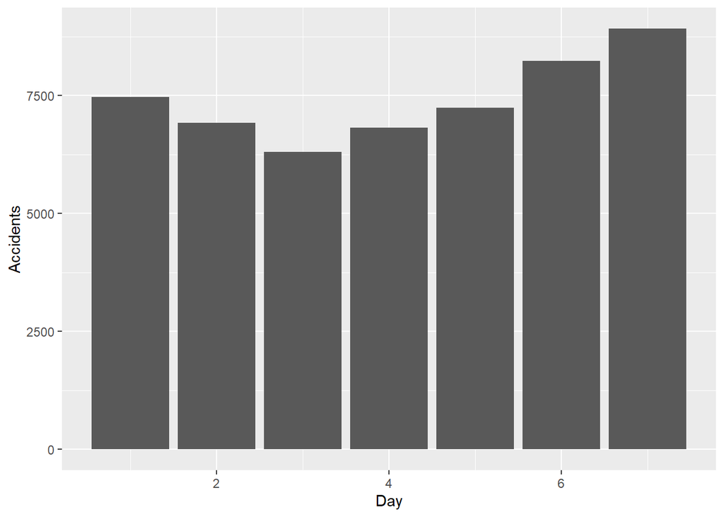

```r
acc.join %>% group_by(DAY_WEEK) %>% tally() %>% ggplot(aes(x=DAY_WEEK, y=n)) + geom_bar(stat = 'identity')  + labs(x='Day', y='Accidents')
```

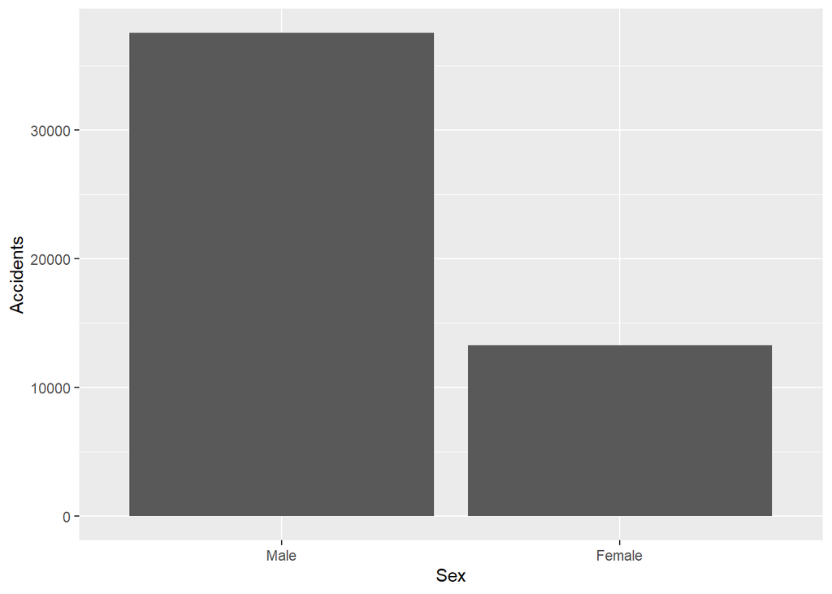

```r
acc.join$SEX <- as.factor(acc.join$SEX)
levels(acc.join$SEX) <- c("Male", "Female", "Not Reported", "Unknown")

acc.join %>%  filter(!((SEX=="Not Reported") | (SEX=="Unknown"))) %>% group_by(SEX) %>% tally() %>% ggplot(aes(x=SEX, y=n)) + geom_bar(stat = 'identity') + labs(x='Sex', y='Accidents')
```

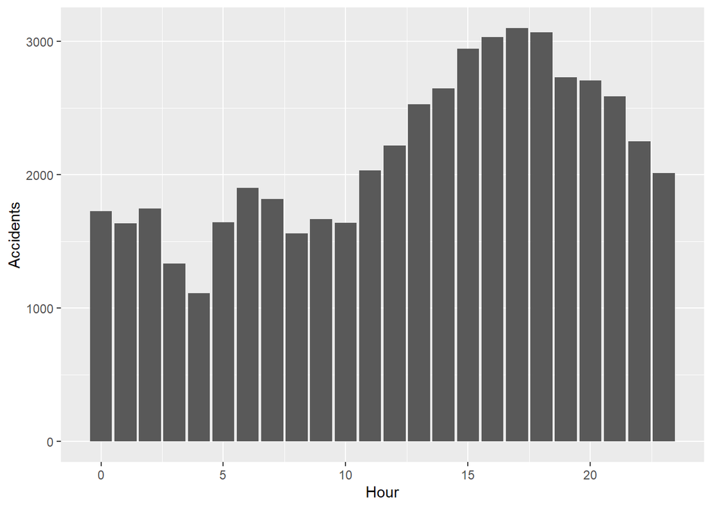

```r
acc.join %>% filter(!HOUR==99) %>% group_by(HOUR) %>% tally() %>%
  ggplot(aes(x=HOUR, y=n)) + geom_bar(stat = 'identity') + labs(x='Hour', y='Accidents')
```